# Missouri Earthquake Data Set

Christopher Prener, Ph.D.

January 13, 2017

## Introduction

This notebook details the creation of a data set of earthquakes in Missouri.

## Project Set Up

Since our notebook resides in a subdirectory of the R project called `doc`, all relative paths to folders as in the `import("data/earthquakes.csv")` are assumed to subdirectories of `doc`. This, of course, is not the case. Rather, we want our notebook to assume that relatve paths of the folder with the R project file in it. We can use

```r
knitr::opts_knit$set(root.dir = here::here())
```

This is a critically important step. It allows us to continue using relative paths **and** a logical, sustainable file system. Moreover, we can do this while also not using the `setwd()` function, which would be used to “hard code” a file path like `setwd("/Users/jsmith/Documents/SOC5650/MOEarthquakes")`. The `here()` function finds a project’s root directory, and can be used to direct `knitr` appropriately. The beauty of this arrangement is that this file can be executed on *any* computer, since `here()` will always resolve to the appropriate project directory for `MOEarthquakes`. Doing so increases the reproducibility of our work.

## Dependencies

The following packages are required for this notebook:

```r
library(dplyr)        # data wrangling
library(ggplot2)      # plotting
library(rio)          # data import
library(sf)           # spatial data tool
library(tigris)       # download census shapefiles
```

## Obtaining Raw Data

The data were obtained from the [USGS Earthquake Catalog](https://earthquake.usgs.gov/earthquakes/search/). The search parameters used were for earthquakes of at least a magnitude of `2.0` between `1973-01-01 00:00:00` and `2017-12-31 23:59:59`. A custom rectanlge around Missouri was drawn that covered the following coordinates - [`35.909, 40.699`] Latitude and [`-95.845, -88.989`] Longitude. These were output as `CSV` data and ordered with the oldest event first. They were saved to the file `earthquakes.csv` available in this repository.

```r
quakes <- import("data/earthquakes.csv")
```

## Cleaning the Earthquake Data

Our first task is the clean the earthquake data. The [USGS Earthquake Catalog](https://earthquake.usgs.gov/earthquakes/search/) does not allow for searching by political geographies but rather requires us to download all earthquakes that occur in a rectangular area. Given Missouri’s shape, this means we have downloaded a number of earthquakes that occured in surrounding states. We want to remove those from our data set, and will do so using a technique called a ‘spatial join’.

### Obtaining Spatial Data

We’ll start by downloading geometric data for all states using the `tigris` package, and then convert it to a simple feature object. Simple feature objects are an effecient and easy way to work with spatial data in `r`. However, they are relatively new and older packages like `tigirs` do not use simple features by default. What we really need is just the Missouri state boundary, so we’ll extract that from the larger data set after we download and convert the data.

```r
# download us states data
us <- states(year = 2015)
# convert to simple feature
us <- st_as_sf(us)
# extract missouri data
mo <- filter(us, GEOID == "29")
# remove states data
rm(us)
```

We can check that the conversion worked by making a simple map of Missouri using the `geom_sf()` geom from `ggplot2`. *This geom is currently only available from the development version, which needs to be downloaded and installed from GitHub.*

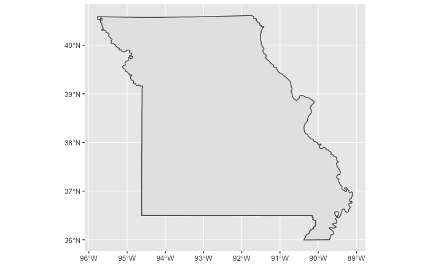

```r
ggplot() +
  geom_sf(data = mo)
```

### Adding Earthquakes to Map

For the next map, we’ll add the earthqukes. The `quakes` data frame includes variables measuring longitude and latitutde, which can be used to “project” the data on the map.

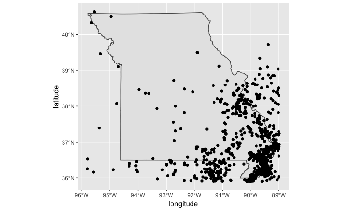

```r
ggplot() +
  geom_sf(data = mo) +
  geom_point(data = quakes, mapping = aes(x=longitude, y=latitude))
```

This map gives a clear sense of our data cleaning task - there are a considerable number of points that fall outside the state boundary that we are not interested in for this exercise.

### Converting `quakes` to a Simple Features

Before we convert our `quakes` data frame (which is a tabular object that contains geometric data) into a geometric object, we need to make a decision about the coordinate system we will use for our data. Since they are already in decimal degrees, and since data from `tigris` uses the NAD1983 standard, we’ll use NAD1983 as well.

The `sf` package includes a tool for confirming which coordinate system is being used by a geometric object:

```r
st_crs(mo)
```

```
Coordinate Reference System:
  EPSG: 4269
  proj4string: "+proj=longlat +ellps=GRS80 +towgs84=0,0,0,0,0,0,0 +no_defs"
```

The EPSG value refers to the identification number of the coordinate system in the EPSG data base. EPSG stands for “European Petroleum Survey Group”. The value `4269` is the EPSG identification number for NAD1983.

With a coordinate system selected, we can convert our object to a geometric one:

```r
quakesGeo <- st_as_sf(quakes, coords = c("longitude", "latitude"), crs = 4269)
```

To check that it converted correctly, we can make a map with it. Notice how the `ggplot()` syntax is simpler with a simple feature object than it is when we are trying to map a data frame.

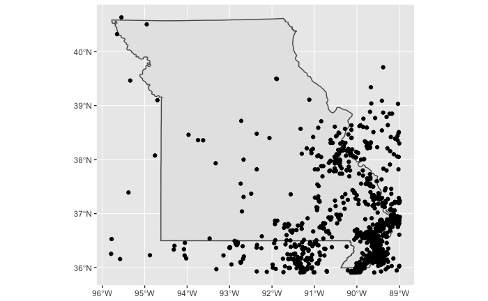

```r
ggplot() +
  geom_sf(data = mo) +
  geom_sf(data = quakesGeo)
```

Our map looks like the previous one!

### Spatial Joins

Our goal with the spatial join is to select only the points on the map that fall within Missouri. We can use the `st_join()` function to accomplish this. The ordering is important here - `quakesGeo`, our point data, should be listed first.

This will produce a geometric object that contains state information applied to each point. If the earthquake is within Missouri, it will have the data from the state geometric data. If it is outside of Missouri, it will have `NA` for the state data columns. We can use `dplyr`’s `filter()` function to extract only the points within Missouri.

This code arrangement is called a “pipeline”. Each time you see the `%>%` operator, think of the word “then”. We can read the pipeline like so:

1. Take the `quakesGeo` data and **then**
2. Combine it with the `mo` data using a spatial join, **then**
3. Extract all of the observations that are within Missouri and
4. Assign the results to a new geometric object named `quakesMO`

The period in `st_join()` is a placeholder, instructing `st_join()` to reference `quakesGeo` at the point in the function where the period appears.

```r
quakesGeo  %>%
  st_join(., mo) %>%
  filter(STUSPS == "MO") -> quakesMO
```

```
although coordinates are longitude/latitude, st_intersects assumes that they are planar
```

We can check our work again by mapping the newly joined data:

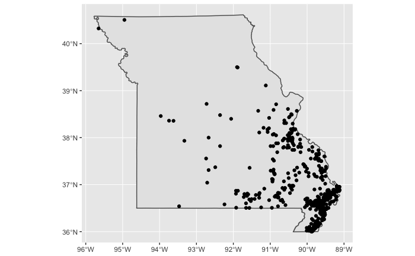

```r
ggplot() +
  geom_sf(data = mo) +
  geom_sf(data = quakesMO)
```

The `st_join()` function will append all of the variables from `mo` to our data as well, so we’ll want to clean up the data frame a bit before moving on.

```r
str(quakesMO)
```

```
Classes ‘sf’ and 'data.frame':  989 obs. of  35 variables:
 $ time           : chr  "1973-01-12T11:56:56.000Z" "1973-10-09T20:15:26.800Z" "1974-04-05T19:41:11.200Z" "1974-05-13T06:52:18.800Z" ...
 $ depth          : num  20 1 1 1 5 5 6 5 5 5 ...
 $ mag            : num  3.2 3.8 2.6 4.3 2 2.1 2.7 3.6 2.3 2.6 ...
 $ magType        : chr  "lg" "lg" "lg" "mb" ...
 $ nst            : int  NA NA NA NA NA NA NA NA NA NA ...
 $ gap            : num  NA NA NA NA NA NA NA NA NA NA ...
 $ dmin           : num  NA NA NA NA NA NA NA NA NA NA ...
 $ rms            : num  NA NA NA NA NA NA NA NA NA NA ...
 $ net            : chr  "us" "us" "us" "us" ...
 $ id             : chr  "usp0000048" "usp00003s8" "usp00005vr" "usp00006b7" ...
 $ updated        : chr  "2014-11-06T23:21:07.594Z" "2014-11-06T23:21:20.747Z" "2014-11-06T23:21:23.608Z" "2017-04-13T21:48:10.676Z" ...
 $ place          : chr  "Missouri" "Missouri" "Missouri" "Missouri" ...
 $ type           : chr  "earthquake" "earthquake" "earthquake" "earthquake" ...
 $ horizontalError: num  NA NA NA NA NA NA NA NA NA NA ...
```

[output cut: 24 more lines]

To keep things simple for this example, we’ll only retain the `time`, `depth`, `mag`, and `place` variables:

```r
quakesMO <- select(quakesMO, time, depth, mag, place)
```

### Writing the Results to a Shapefile

Before we continue, we’ll write the results of our geoprocessing to a shapefile so we can use the data later without re-creating it. This will also allow us to open the shapefile in a program like ArcGIS if we wanted to produce a more finished looking map. We’ll want to create a folder in the `results` subdirectory to store these files:

```r
dir.create("results/GEO_Earthquakes")
```

With the folder made, we can save the shapefile:

```r
st_write(quakesMO, "results/GEO_Earthquakes/GEO_Earthquakes.shp")
```

```
Writing layer `GEO_Earthquakes' to data source `results/GEO_Earthquakes/GEO_Earthquakes.shp' using driver `ESRI Shapefile'
features:       989
fields:         4
geometry type:  Point
```

We’ll also write these data as a .geojson file so that they can be previewed on GitHub. GeoJSON files are plain-text versions of shapefiles.

```r
st_write(quakesMO, "results/GEO_Earthquakes/GEO_Earthquakes.geojson")
```

```
Writing layer `GEO_Earthquakes' to data source `results/GEO_Earthquakes/GEO_Earthquakes.geojson' using driver `GeoJSON'
features:       989
fields:         4
geometry type:  Point
```